# ASA DataFest 2019

In our project, we first tried to examine whether the current overall measurement of fatigue, “Monotoring Score” can be improved or not. To do this, we noticed that if “Monitoring Score” is indeed a good overall measure of fatigue, then for groups of players who believe they were performing better than usual in the current game, we should expect their “Monitoring Score” are on average larger than that of groups of players who think they didnot perform as well as usual in the games.

We can use two sample t-test as follows:

```
##
##  F test to compare two variances
##
## data:  ANOVA$MonitoringScore[ANOVA$BestOutOfMyself == "Not at all"] and ANOVA$MonitoringScore[ANOVA$BestOutOfMyself == "Absolutely"]
## F = 0.77258, num df = 10, denom df = 46, p-value = 0.692
## alternative hypothesis: true ratio of variances is not equal to 1
## 95 percent confidence interval:
##  0.3299648 2.4979691
## sample estimates:
## ratio of variances
##          0.7725843
```

Since the two groups have variances not significantly different from each other, we can use pooled variance two sample t-tests.

```r
t.test(ANOVA$MonitoringScore[ANOVA$BestOutOfMyself=="Not at all"],
       ANOVA$MonitoringScore[ANOVA$BestOutOfMyself=="Absolutely"], var.equal = T)
```

```
##
##  Two Sample t-test
##
## data:  ANOVA$MonitoringScore[ANOVA$BestOutOfMyself == "Not at all"] and ANOVA$MonitoringScore[ANOVA$BestOutOfMyself == "Absolutely"]
## t = -0.97797, df = 56, p-value = 0.3323
## alternative hypothesis: true difference in means is not equal to 0
## 95 percent confidence interval:
##  -3.354976  1.153816
## sample estimates:
## mean of x mean of y
##  16.09091  17.19149
```

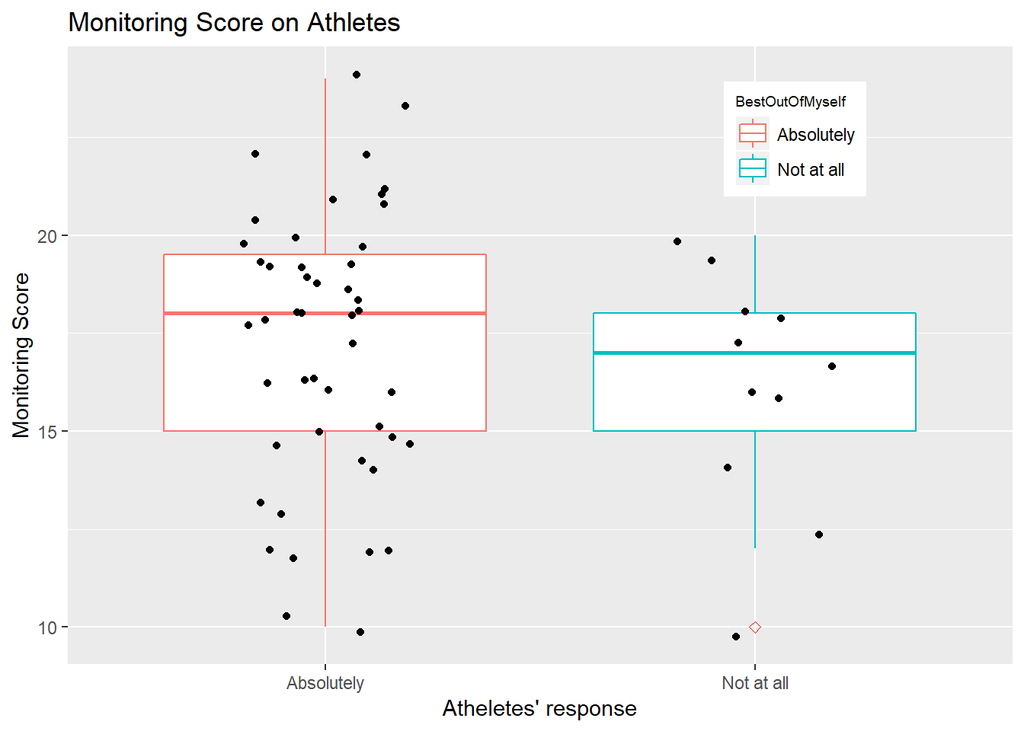

We can then check the assumptions of the two sample t-tests.

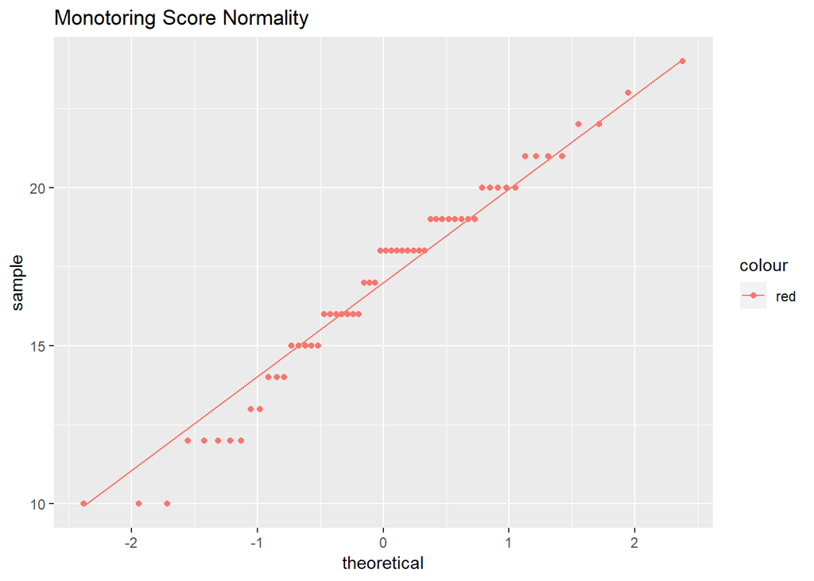

It seems that normality assumption is satisfied.

However, based on the boxplots, these two groups seem to have similar “Monitoring Scores” instead. Does that mean these five subjective measures of fatigues are totally useless? Maybe not! Since we know that even though those measures are subjective and may even be biased in some ways, they are still very good proxy to the real physical fatigue levels of players. Therefore, we just need to find a more efficient way to use this information.

To do that, we decided to apply PCA on these five standardized subjective features, and the reason that we standardized these features is to take in to account the individual’s variations. Using R, we found all of the principal component vectors, and we noticed that the first principal component vector alone explains the most of variability among these features.

```r
X <- select(PlayerinGame,"stdFatigue","stdSoreness","stdDesire","stdIrritability","stdSleepQuality")
PCA <- prcomp(X)
summary(PCA)
```

```
## Importance of components:
##                           PC1    PC2    PC3     PC4     PC5
## Standard deviation     1.9446 1.0402 0.8810 0.72307 0.63539
## Proportion of Variance 0.5759 0.1648 0.1182 0.07962 0.06148
## Cumulative Proportion  0.5759 0.7407 0.8589 0.93852 1.00000
```

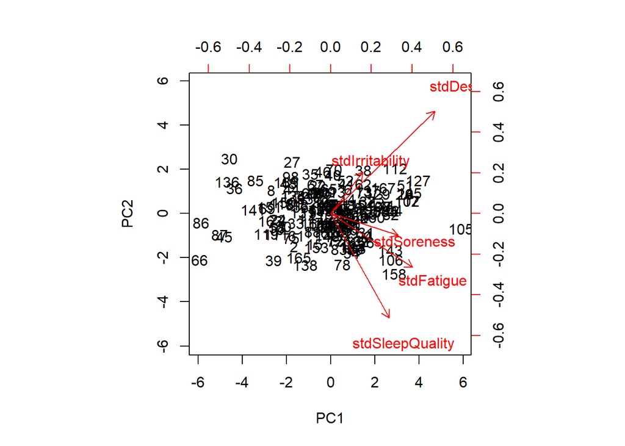

```r
biplot(PCA$x,PCA$rotation[,1:2])
```

```r
X1 <- mutate(X,Subjective_Score=as.matrix(X)%*%PCA$rotation[,1])
X1$SleepHours <- PlayerinGame$SleepHours
PlayerinGame$Sscore <- X1$Subjective_Score
Weights_for_Subjective <- PCA$rotation[,1]
```

Now, we claim that this “Sscore” computed using PCA, will be much better than “Monitoring Scores”, since first principal component vector by definition is the best direction in terms of efficiently utilizing all the information in the feature space. To confirm that, we can do a pooled t-test between Sscores of players with higher self-rating and Sscores of players with lower self-rating.

```
##
##  F test to compare two variances
##
## data:  ANOVA$Sscore[ANOVA$BestOutOfMyself == "Not at all"] and ANOVA$Sscore[ANOVA$BestOutOfMyself == "Absolutely"]
## F = 0.91529, num df = 10, denom df = 46, p-value = 0.9449
## alternative hypothesis: true ratio of variances is not equal to 1
## 95 percent confidence interval:
##  0.3909133 2.9593745
## sample estimates:
## ratio of variances
##          0.9152901
```

This shows that we can use pooled two sample t-tests,

```r
t.test(ANOVA$Sscore[ANOVA$BestOutOfMyself=="Not at all"],
       ANOVA$Sscore[ANOVA$BestOutOfMyself=="Absolutely"],var.equal = T)
```

```
##
##  Two Sample t-test
##
## data:  ANOVA$Sscore[ANOVA$BestOutOfMyself == "Not at all"] and ANOVA$Sscore[ANOVA$BestOutOfMyself == "Absolutely"]
## t = -1.7097, df = 56, p-value = 0.09286
## alternative hypothesis: true difference in means is not equal to 0
## 95 percent confidence interval:
##  -2.7834244  0.2200434
## sample estimates:
##  mean of x  mean of y
## -1.1142097  0.1674807
```

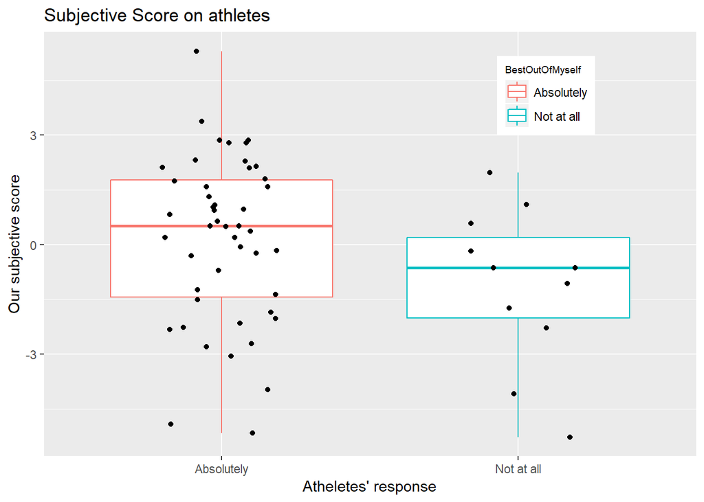

Now we can check the normality assumption,

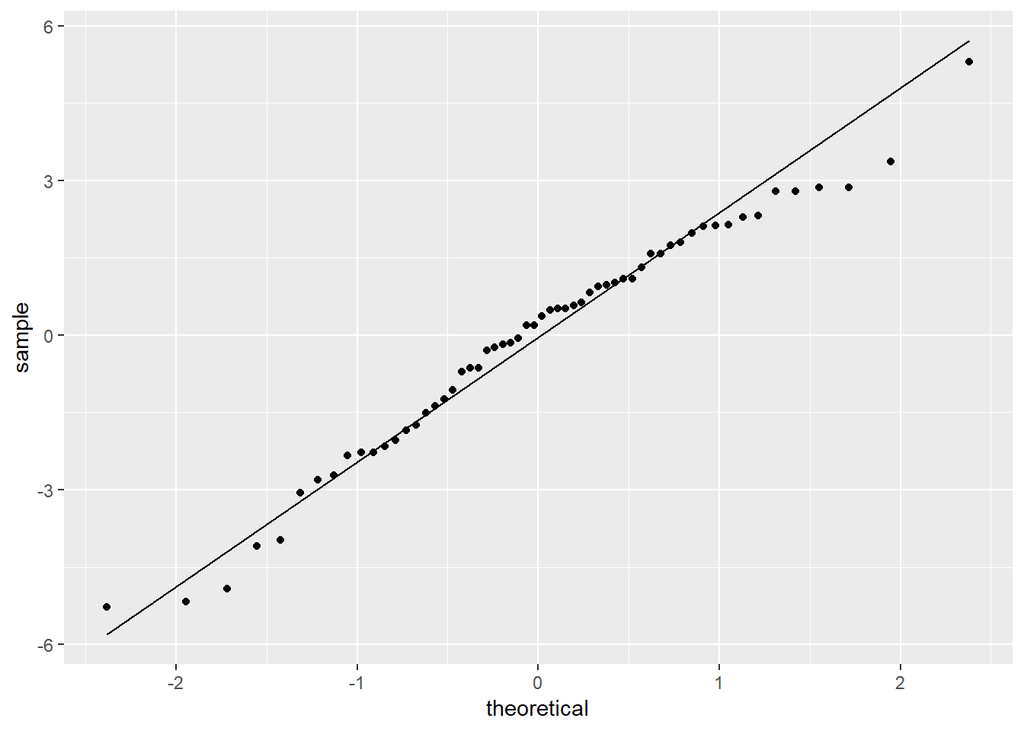

Furthermore, with our new overall measurement of player’s fatigue, some more intriguing relationship between fatigues and performance can be found and utilized to form useful auxiliary tools for the coaches to refer to during the games. We constructed a new variable to measure the use of overall energy a player used during every half game called “Oscore”. Again, it is calculated using weighted sum of objective measurements from gps data, and the weights are given by the first principal component.

It is important to understand the intuitions of the two measures that we gave: “Sscore” represents self-perceived mental status at the beginning of a day, the higher it is, the more positive the player perceives herself to be, and “Oscore” represents physical energy consumed at the end of a half game, the higher it is, the more fatigue the player should feel. How are those quantitate measures useful in an actual game?